# LT1_Final_Project

```python
from IPython.display import HTML, Image
HTML('''
<script
    src="https://cdnjs.cloudflare.com/ajax/libs/jquery/2.0.3/jquery.min.js ">
</script>
<script>
code_show=true;
function code_toggle() {
 if (code_show){
 $('div.jp-CodeCell > div.jp-Cell-inputWrapper').hide();
 } else {
$('div.jp-CodeCell > div.jp-Cell-inputWrapper').show();
 }
 code_show = !code_show
}
$( document ).ready(code_toggle);
</script>
<form action="javascript:code_toggle()"><input type="submit"
    value="Click here to toggle on/off the raw code."></form>
''')
```

[figure not shown]

```python
image_path = 'Banner_proj.png'

Image(filename=image_path)
```

```python
import numpy as np
import pandas as pd
from sklearn.decomposition import TruncatedSVD
import matplotlib.pyplot as plt
import re

import warnings
warnings.filterwarnings("ignore")
warnings.filterwarnings('ignore', 'Glyph.*missing from current font.')
```

```python
def get_channel_info(channel_id):
    """
    Retrieves information about a YouTube channel.

    Parameters:
    channel_id (str): The YouTube channel ID.
    api_key (str): The API key for accessing YouTube Data API.

    Returns:
    tuple: A tuple containing raw channel data and structured channel
    information.

    Raises:
    ValueError: If the response from the API is not successful.
    """

    if not channel_id or not api_key:
        raise ValueError("Channel ID and API key are required")

    channel_ep = 'https://www.googleapis.com/youtube/v3/channels'
    params = {
        'part': ('id,snippet,statistics,contentDetails,topicDetails,'
                 'brandingSettings'),
        'id': channel_id,
        'key': api_key
    }

    try:
        response = requests.get(channel_ep, params=params)
        if response.status_code != 200:
            raise ValueError(f"API request failed with status code"
                             f" {response.status_code}")

        content = response.json()
        item = content.get('items', [{}])[0]

        title = item.get('snippet', {}).get('title', 'Unknown')
        desc = item.get('snippet', {}).get('description', 'No description')
        country = item.get('snippet', {}).get('country', 'None')
        topic_categ = item.get('topicDetails', {}).get('topicCategories', [])
        view_count = item.get('statistics', {}).get('viewCount', '0')
        sub_count = item.get('statistics', {}).get('subscriberCount', '0')
        vid_count = item.get('statistics', {}).get('videoCount', '0')
        keywords = (item.get('brandingSettings', {}).get('channel', {})
                    .get('keywords', 'None'))

        needed_info = {
            'title': title,
            'description': desc,
            'country': country,
            'topic_categories': topic_categ,
            'view_count': view_count,
            'subscriber_count': sub_count,
            'video_count': vid_count,
            'keywords': keywords
        }

        return item, needed_info

    except requests.RequestException as e:
        logging.error(f"Network error occurred: {e}")
        raise
    except ValueError as e:
        logging.error(f"API response error: {e}")
        raise
    except Exception as e:
        logging.error(f"Unexpected error occurred: {e}")
        raise
```

```python
def plot_explained_var(var_exp_norm, target_variance):
    """
    Create a line graph for the variance explained.

    Parameters:
    - var_exp_norm (numpy.ndarray): Array of individual explained variance for
    each singular value.
    - target_variance (float): Target cumulative explained variance to mark on
    the graph.

    Returns:
    None
    """
    components_for_target = np.argmax(var_exp_norm.cumsum() >= target_variance)
    plt.figure(figsize=(10, 5))
    plt.plot(var_exp_norm, label='Individual Explained Variance', color='red',
             lw=2)
    plt.plot(var_exp_norm.cumsum(), label='Cumulative Explained Variance',
             color='blue', lw=2)
    plt.axhline(y=target_variance, color='green', linestyle='--',
                label=f'{target_variance * 100}% Explained Variance')
    plt.axvline(x=components_for_target, color='green', linestyle='--')
    plt.xlabel('SV')
    plt.ylabel('Explained Variance')
    plt.title('Explained Variance per SV')
    plt.legend(loc='best')
    plt.tight_layout();


def plot_sv_bars(svs, num_svs, feature_names):
    """
    Create bar plots for the singular values.

    Parameters:
    - svs (numpy.ndarray): Matrix of singular values.
    - num_svs (int): Number of singular values to plot.
    - feature_names (list): List of feature names.

    Returns:
    None
    """
    for i in range(num_svs):
        fig, ax = plt.subplots()
        order = np.argsort(np.abs(svs[:, i]))[-10:]
        ax.barh([feature_names[o] for o in order], svs[order, i],
                color="#FF0001")
        ax.set_title(f'SV{i + 1}');

def get_sv_num(var_exp_norm, target_variance):
    """
    Get the number of singular values needed to achieve the target cumulative
    explained variance.

    Parameters:
    - var_exp_norm (numpy.ndarray): Array of individual explained variance for
    each singular value.
    - target_variance (float): Target cumulative explained variance.

    Returns:
    int: Number of singular values required to achieve the target cumulative
    explained variance.
    """
    components_for_target_label = (np.argmax(var_exp_norm.cumsum() >=
                                             target_variance) + 1)
    return components_for_target_label
```

# Alike and Subscribe

#### A demonstration on how effective dimensionality reduction techniques can uncover themes that can effect better channel segmentation of YouTube channels.

## Abstract

This research focuses on investigating YouTube's highly influential algorithm, a cornerstone of the platform's personalized recommendation system. Despite its significant role in shaping user experience, detailed knowledge of its functionality remains largely confined within Google's proprietary boundaries. This study aims to contribute to the broader understanding of YouTube and its algorithm, offering insights of interest to a diverse audience.

Employing advanced dimensionality reduction techniques, specifically Single Value Decomposition (SVD) and Latent Semantic Analysis (LSA), this study successfully extracted latent variables from a geographically specific dataset. The findings not only illuminate aspects of the algorithm's operation but also highlight its geographic nuances. The research concludes with a set of recommendations to address the study's inherent limitations and suggests directions for future research that can build upon these initial findings.

## Problem Statement

In today’s digital era, video content has become a dominant form of media consumption. Understanding the characteristics that drive video content reigns supreme as a key medium of media consumption. For content creators and marketers, grasping what factors contribute to a video’s success – be it the relevance of its topic or its appeal in different regions – is vital. This study sets out to explore these contributing factors using detailed datasets. A thorough analysis of these elements is poised to uncover hidden trends and preferences in video consumption on a global scale.

Despite significant research and documentation, the inner workings of YouTube's recommendation algorithm remain a closely guarded secret within Google's corporate confines. This lack of transparency poses a significant challenge for researchers, policymakers, content creators, and users who seek to understand and ethically engage with the platform.

This study aims to address such need through the lenses of latent variables that could arise through dimensionality reduction techniques and analysis.

## Motivation

The study holds significant motivations and implications in several critical areas. Firstly, it aims to enhance digital transparency by unraveling the workings of YouTube's algorithm - something crucial in understanding how content is curated and distributed. This insight is invaluable for informing policy and regulation, as it can guide lawmakers and regulators in developing fair and unbiased content distribution guidelines to protect user interests.

Additionally, the study supports content creators by providing insights into how geographic factors influence content visibility, aiding them in effectively reaching their target audiences.

Academically, the research contributes valuable knowledge to fields like algorithmic analysis and digital media studies, offering methodologies potentially applicable to other digital platforms. It also plays a vital role in improving user experience by highlighting potential biases in content recommendations, leading to a more inclusive and diverse user experience on YouTube.

Lastly, the findings can guide the development of ethical and user-centric algorithms, shaping future technologies for the broader benefit of society. Overall, this study addresses essential aspects of digital ethics, regulatory needs, content creation strategies, academic inquiry, user inclusivity, and technological advancement, making it a pivotal contribution to the digital media landscape.

## Data Source

### List of Top YouTubers

Given the limitations in YouTube API, a separate website (https://vidiq.com/youtube-stats/top/500/) with information on the top 250 channels based on the subscriber count was scraped.

The proposed system uses YouTube Data API (https://developers.google.com/youtube/v3) to call each channel found in the Top 250 list. These 250 channels will serve as the dimensionality reduction system’s corpus when looking to categorize the channels.

```python
# Loading the DataFrames
non_text_df = pd.read_csv('non_text_df.csv')
bag_kw = pd.read_csv('bag_of_keywords.csv')
country_df = pd.read_csv('country_df.csv')
topics_df = pd.read_csv('topics_df.csv')
```

```python
num_comp = non_text_df.shape[0]
```

### Metrics to Be Retrieved

The API is used to call several channel details which will be used to create a profile of each channel in order to distinguish them from and to compare them to other channels.

1. title: string

##### The name of the YouTube channel.

2. country: string

##### The country where the channel is based.

3. topic_categories: list

##### A list of Wikipedia URLs that describe the channel's content.

4. view_count: int

##### The total number of views of all videos the channel has uploaded.

5. subscriber_count: int

##### The total number of users subscribed to the channel.

6. video_count: int

##### The total number of videos a channel has uploaded.

7. keywords: list

##### Terms that give YouTube information and context about the channel, such as the type of content produced, and who the channel’s target audience is. Keywords are determined and set by the channel owner.

## Methodology

### Overview

Figure 1.1. visually represents the processes used from the acquisition of data sets to the interpretation of results.

[figure not shown]

```python
image_path = 'meth1.png'

Image(filename=image_path, width=1080, height=720)
```

### Details

#### Data Acquisition

As discussed above, the list of top 250 channels was web scraped from vidIQ. Using this list, the group manually looked up the unique IDs for each channel. The function ‘get_channel_info’ was created to pull relevant data from YouTube API using the channel IDs. Note, pulling data from the API is possible using the channel names, but using unique IDs ensured the right channel was selected. The raw database is shown below.

```python
raw_data = pd.read_csv('Lab2_DataBase.csv')
print("Figure 1.2. First 5 entries in the raw dataset")
display(raw_data.head())
```

```
Figure 1.2. First 5 entries in the raw dataset
```

|  | title | description | country | topic_categories | view_count | subscriber_count | video_count | keywords |
| --- | --- | --- | --- | --- | --- | --- | --- | --- |
| 0 | T-Series | "Music can change the world". T-Series is Indi... | IN | ['https://en.wikipedia.org/wiki/Music', 'https... | 238030852574 | 253000000 | 19820 | "tseries tseries" t-series "tseries songs" "di... |
| 1 | MrBeast | SUBSCRIBE FOR A COOKIE!\nAccomplishments:\n- R... | US | ['https://en.wikipedia.org/wiki/Lifestyle_(soc... | 36996755250 | 211000000 | 767 | mrbeast6000 beast mrbeast Mr.Beast mr |
| 2 | Cocomelon - Nursery Rhymes | At CoComelon, our primary goal has always been... | US | ['https://en.wikipedia.org/wiki/Entertainment'... | 170365245506 | 167000000 | 1036 | "nursery rhymes" "baby songs" "nursery songs" ... |
| 3 | SET India | Sony Entertainment Television is one of the le... | IN | ['https://en.wikipedia.org/wiki/Television_pro... | 153953696545 | 165000000 | 121686 | "SET India" "Sony Entertainment Television" "S... |
| 4 | ✿ Kids Diana Show | Welcome to Diana and Roma world - where Diana,... | US | ['https://en.wikipedia.org/wiki/Lifestyle_(soc... | 96980699954 | 115000000 | 1136 | "diana and roma" diana "roma and diana" "kids ... |

#### Preprocessing and Data Exploration

In this part, the goal is to try to understand the characteristics and structure of a dataset before formal analysis using various methods to gain insights into the data and identify patterns.

Two columns identified will be key to this study: countries and keywords.

No duplicates were found across the entire dataset. Empty cells were identified in the ‘country’ and ‘keywords’ columns. To address these, the .fillna() method was used to allow these cells to return None. These values were kept to retain potential insights on the platform’s algorithm.

For the purposes of the 2-Step SVD method, the group needed to split the dataset into the text and non-text data.

##### Text Data

The group used Onehot encoder to properly label values in the ‘country’ column. Given it was a list, the ‘topic_categories’ needed to be split first and flattened using string methods. The columns ‘keywords’, which is a list, were tokenized to create the Bag of Words using the custom function ‘custom_tokenizer.’

```python
# B-o-W Creation

import pandas as pd
import numpy as np
from sklearn.preprocessing import OneHotEncoder
from sklearn.feature_extraction.text import TfidfVectorizer


# Redefining the custom tokenizer
def custom_tokenizer(text):
    """
    Redefine the custom tokenizer.

    This function takes a text input and tokenizes it based on the provided
    pattern. The pattern matches phrases within double quotes and single words
    separated by spaces.

    Parameters
    ----------
    text : str
        The input text to be tokenized.

    Returns
    -------
    list of str
        A list of tokens extracted from the input text.
    """
    # Matches phrases within quotes and single words separated by spaces
    pattern = r'"([^"]+)"|(\w+)'
    tokens = re.findall(pattern, text)
    # Flatten the list of tuples and filter out empty strings
    return [token for pair in tokens for token in pair if token]

# Load the CSV file
lab2_db = pd.read_csv('Lab2_DataBase.csv')
raw_data = lab2_db.copy()

# Fill missing values with an empty string
lab2_db['keywords'].fillna('', inplace=True)


# One-Hot Encode the 'country' Column
onehot_encoder = OneHotEncoder(sparse_output=False)
country_encoded = (onehot_encoder.fit_transform(lab2_db['country']
                                                .values.reshape(-1, 1)))
country_encoded_df = pd.DataFrame(
    country_encoded,
    columns=onehot_encoder.get_feature_names_out(['country'])
)

# Create a Bag of Words using TF-IDF with the custom tokenizer for 'keywords'
tfidf_vectorizer = TfidfVectorizer(tokenizer=custom_tokenizer,
                                   token_pattern=None)
tfidf_bag_of_words = tfidf_vectorizer.fit_transform(lab2_db['keywords'])
tfidf_bag_of_words_df = pd.DataFrame(
    tfidf_bag_of_words.toarray(),
    columns=tfidf_vectorizer.get_feature_names_out()
)

lab2_db.fillna(0, inplace=True)

# Concatenate all the created DataFrames along with the original data
data_trim = lab2_db[['title']]
final_df1 = pd.concat([data_trim,
                       country_encoded_df,
                       tfidf_bag_of_words_df], axis=1)


# Concatenate all the created DataFrames along with the original data
# Without  video_video_ratio
final_df2 = pd.concat([data_trim, country_encoded_df,
                       tfidf_bag_of_words_df], axis=1)

core_df = tfidf_bag_of_words_df
```

```python
print("Figure 1.3. First 5 Entries of Text dataset")
display(tfidf_bag_of_words_df.head())
```

```
Figure 1.3. First 5 Entries of Text dataset
```

|  |  | avatar | blaze | #beterböcük #shorts #tiktok | #motivation #emotional #acting | 0-2 years old | 10 mais inacreditáveis | 10 melhores | 123s | 15 | ... | 천상지희 | 천상지희더그레이스 | 택연 | 투에이엠 | 투피엠 | 트랙스 | 틱톡김프로 | 페이 | 피프틴앤드 | 혜림 |
| --- | --- | --- | --- | --- | --- | --- | --- | --- | --- | --- | --- | --- | --- | --- | --- | --- | --- | --- | --- | --- | --- |
| 0 | 0.0 | 0.0 | 0.0 | 0.0 | 0.0 | 0.0 | 0.0 | 0.0 | 0.0 | 0.0 | ... | 0.0 | 0.0 | 0.0 | 0.0 | 0.0 | 0.0 | 0.0 | 0.0 | 0.0 | 0.0 |
| 1 | 0.0 | 0.0 | 0.0 | 0.0 | 0.0 | 0.0 | 0.0 | 0.0 | 0.0 | 0.0 | ... | 0.0 | 0.0 | 0.0 | 0.0 | 0.0 | 0.0 | 0.0 | 0.0 | 0.0 | 0.0 |
| 2 | 0.0 | 0.0 | 0.0 | 0.0 | 0.0 | 0.0 | 0.0 | 0.0 | 0.0 | 0.0 | ... | 0.0 | 0.0 | 0.0 | 0.0 | 0.0 | 0.0 | 0.0 | 0.0 | 0.0 | 0.0 |
| 3 | 0.0 | 0.0 | 0.0 | 0.0 | 0.0 | 0.0 | 0.0 | 0.0 | 0.0 | 0.0 | ... | 0.0 | 0.0 | 0.0 | 0.0 | 0.0 | 0.0 | 0.0 | 0.0 | 0.0 | 0.0 |
| 4 | 0.0 | 0.0 | 0.0 | 0.0 | 0.0 | 0.0 | 0.0 | 0.0 | 0.0 | 0.0 | ... | 0.0 | 0.0 | 0.0 | 0.0 | 0.0 | 0.0 | 0.0 | 0.0 | 0.0 | 0.0 |

5 rows × 3061 columns

##### Non-text Data

The group used Onehot encoder to properly label values in the ‘country’ column which, along with the results of the first stage of SVD, will make up the Non-text dataset.

```python
print("Figure 1.4. First 5 Entries of Onehot Encoded Countries Dataset")
display(country_encoded_df.head())
```

```
Figure 1.4. First 5 Entries of Onehot Encoded Countries Dataset
```

|  | country_AE | country_AR | country_AU | country_BR | country_CA | country_CL | country_CO | country_DE | country_ES | country_GB | ... | country_NL | country_NO | country_PH | country_PK | country_PR | country_SV | country_TH | country_TR | country_US | country_nan |
| --- | --- | --- | --- | --- | --- | --- | --- | --- | --- | --- | --- | --- | --- | --- | --- | --- | --- | --- | --- | --- | --- |
| 0 | 0.0 | 0.0 | 0.0 | 0.0 | 0.0 | 0.0 | 0.0 | 0.0 | 0.0 | 0.0 | ... | 0.0 | 0.0 | 0.0 | 0.0 | 0.0 | 0.0 | 0.0 | 0.0 | 0.0 | 0.0 |
| 1 | 0.0 | 0.0 | 0.0 | 0.0 | 0.0 | 0.0 | 0.0 | 0.0 | 0.0 | 0.0 | ... | 0.0 | 0.0 | 0.0 | 0.0 | 0.0 | 0.0 | 0.0 | 0.0 | 1.0 | 0.0 |
| 2 | 0.0 | 0.0 | 0.0 | 0.0 | 0.0 | 0.0 | 0.0 | 0.0 | 0.0 | 0.0 | ... | 0.0 | 0.0 | 0.0 | 0.0 | 0.0 | 0.0 | 0.0 | 0.0 | 1.0 | 0.0 |
| 3 | 0.0 | 0.0 | 0.0 | 0.0 | 0.0 | 0.0 | 0.0 | 0.0 | 0.0 | 0.0 | ... | 0.0 | 0.0 | 0.0 | 0.0 | 0.0 | 0.0 | 0.0 | 0.0 | 0.0 | 0.0 |
| 4 | 0.0 | 0.0 | 0.0 | 0.0 | 0.0 | 0.0 | 0.0 | 0.0 | 0.0 | 0.0 | ... | 0.0 | 0.0 | 0.0 | 0.0 | 0.0 | 0.0 | 0.0 | 0.0 | 1.0 | 0.0 |

5 rows × 28 columns

### Split/Two-Step SVD

The methodology of the study incorporates Single Value Decomposition (SVD) for feature reduction in the dataset. SVD, a fundamental technique in linear algebra, decomposes an $n \times d$ matrix $\mathbf{D}$ into three matrices: $\mathbf{D} = \mathbf{Q\Sigma P}^T$. Here, $\mathbf{Q}$ is an $n \times n$ matrix with orthonormal columns representing the left singular vectors, $\mathbf{\Sigma}$ is an $n \times d$ diagonal matrix consisting of singular values, and $\mathbf{P}$ is a $d \times d$ matrix of orthonormal columns, denoting the right singular vectors.

To streamline the SVD process, the study employs the TruncatedSVD function from the scikit-learn library. A noteworthy aspect of this study's methodology is the implementation of a two-step SVD process. The first step applies SVD to textual data, such as Bag-of-Words representations, while the second step involves applying SVD to a combination of the singular values derived from the first step and the non-textual data.

Following each SVD operation, the study utilizes custom functions, 'get_sv_num' and 'plot_explained_var', to graphically represent the explained variance. These functions are instrumental in determining the optimal number of singular values required to capture a specified proportion of the cumulative explained variance within the dataset.

The rationale behind using this dual process is to avoid potential representation issues that might arise due to the varying sizes of data. Keywords, contained in the bag-of-words, amount to over 3000 columns. Combining that with other features whose columns are in the tens, could lead to said features becoming muted during SVD and analysis. To avoid this, SVs from the first SVD will be used with non-textual data to reduce the weight of representation during the second SVD. This process also helps group together similar keywords into categories, which helps in extracting insights.

```python
t6_text_data = bag_kw
t6_svd_text = TruncatedSVD(n_components=num_comp)
t6_text_transformed = t6_svd_text.fit_transform(t6_text_data)
t6_var_exp = t6_svd_text.explained_variance_ratio_
t6_text_svd_components = t6_svd_text.components_.T
```

### Latent Semantic Analysis

The study then progresses to Latent Semantic Analysis (LSA), conducted after the dual SVD steps. LSA is employed to unearth potential latent variables by examining the singular values and identifying prominent features. The aim is to aggregate these findings and discern potential categories or archetypes characterizing each singular value. To facilitate this analysis, the study introduces a custom function, 'plot_sv_bars', designed to generate horizontal bar plots. These visual representations aid in the more straightforward examination and interpretation of the latent variables associated with each singular value, enhancing the study's analytical depth.

## Results & Discussion

It is important to note that the research team conducted multiple iterations of the methodology, employing various combinations of textual and non-textual data from the acquired dataset.

However, the most elucidating results, from which valuable insights could be derived, were obtained by utilizing a combination of text data in the form of keywords (bag-of-words) and non-text data represented by country information through one-hot encoding.

Interested readers can refer to the appendix of this document for an illustrated overview of the results of alternative trials conducted.

### First Stage Singular Value Decomposition

```python
t6_sv_df = pd.DataFrame(t6_text_transformed)
t6_sv_df.columns = ['SV ' + str(col) for col in range(1, t6_sv_df.shape[0]+1)]
print("Figure 2.1. 250 First Stage SVs")
display(t6_sv_df)
```

```
Figure 2.1. 250 First Stage SVs
```

|  | SV 1 | SV 2 | SV 3 | SV 4 | SV 5 | SV 6 | SV 7 | SV 8 | SV 9 | SV 10 | ... | SV 241 | SV 242 | SV 243 | SV 244 | SV 245 | SV 246 | SV 247 | SV 248 | SV 249 | SV 250 |
| --- | --- | --- | --- | --- | --- | --- | --- | --- | --- | --- | --- | --- | --- | --- | --- | --- | --- | --- | --- | --- | --- |
| 0 | 2.351164e-02 | 1.323114e-02 | 1.569308e-02 | 4.638345e-02 | 1.564584e-01 | 3.189121e-01 | 4.652226e-02 | 2.358120e-01 | 1.032185e-01 | 3.791515e-02 | ... | -2.032879e-19 | -3.686287e-18 | 2.168404e-19 | 2.168404e-19 | 1.626303e-19 | -8.673617e-19 | -1.084202e-18 | -1.355253e-19 | 1.463673e-18 | -2.602085e-18 |
| 1 | 9.924097e-04 | 2.705415e-03 | 4.857232e-03 | 5.488015e-02 | -8.639711e-02 | 9.347384e-03 | -1.194709e-01 | 6.142205e-02 | 5.551420e-02 | -2.380579e-02 | ... | 9.080193e-19 | -2.486889e-18 | -1.843144e-18 | -2.385245e-18 | 8.131516e-18 | -2.602085e-18 | 2.553296e-17 | 5.217723e-19 | 1.214306e-17 | 8.077306e-18 |
| 2 | 4.966700e-01 | -1.078071e-01 | -3.646013e-01 | 5.546537e-02 | -4.066376e-03 | -9.056323e-03 | 3.420274e-02 | 2.957545e-03 | 1.618676e-02 | -2.346140e-02 | ... | -1.734723e-18 | -3.469447e-18 | 3.211949e-18 | -1.929880e-17 | -1.799776e-17 | -6.288373e-18 | -1.040834e-17 | -7.413232e-18 | -2.493665e-18 | 1.517883e-18 |
| 3 | 1.902545e-04 | 5.666711e-04 | 5.737018e-04 | 5.987007e-03 | -1.391809e-03 | -1.073207e-04 | 1.100801e-02 | 2.125174e-03 | 2.637005e-03 | -3.361817e-03 | ... | -6.513683e-19 | 1.301043e-18 | -4.845028e-18 | 7.860466e-18 | 1.913617e-17 | 3.068292e-17 | -1.265806e-17 | 1.685934e-17 | -1.338990e-17 | 1.097755e-17 |
| 4 | 4.337057e-01 | -9.499720e-02 | 2.181100e-01 | -9.095895e-02 | 7.608605e-02 | -2.179149e-02 | 1.618382e-01 | 5.589768e-02 | 9.824602e-02 | -2.621273e-02 | ... | 1.246832e-18 | -1.301043e-18 | 3.794708e-19 | -2.320193e-17 | -8.890458e-18 | -9.147956e-19 | 7.155734e-18 | -9.324139e-18 | 9.649399e-18 | -1.520594e-17 |
| ... | ... | ... | ... | ... | ... | ... | ... | ... | ... | ... | ... | ... | ... | ... | ... | ... | ... | ... | ... | ... | ... |
| 245 | 0.000000e+00 | 0.000000e+00 | 0.000000e+00 | 0.000000e+00 | 0.000000e+00 | 0.000000e+00 | 0.000000e+00 | 0.000000e+00 | 0.000000e+00 | 0.000000e+00 | ... | 0.000000e+00 | 0.000000e+00 | 0.000000e+00 | 0.000000e+00 | 0.000000e+00 | 0.000000e+00 | 0.000000e+00 | 0.000000e+00 | 0.000000e+00 | 0.000000e+00 |
| 246 | 3.431538e-03 | 7.810318e-03 | 8.729544e-04 | 1.459570e-02 | -1.644373e-03 | 6.711333e-02 | -1.898289e-02 | -1.831323e-01 | 1.206190e-01 | 4.404189e-02 | ... | 2.439455e-18 | -2.168404e-19 | -9.540979e-18 | 1.544988e-18 | 1.084202e-19 | -1.539567e-17 | -2.103352e-17 | 7.806256e-18 | -2.623769e-17 | 1.301043e-18 |
| 247 | 1.537451e-18 | 6.025133e-17 | 5.317069e-17 | 2.181114e-18 | 1.666492e-16 | -8.780161e-17 | 2.439164e-17 | 2.000671e-16 | -1.529501e-16 | 3.160253e-16 | ... | 6.017322e-17 | -1.149254e-17 | 6.020033e-17 | 5.198749e-17 | -3.285133e-17 | -1.160638e-16 | -2.604796e-17 | 5.789640e-17 | 1.084202e-18 | -1.138412e-18 |
| 248 | 6.245946e-02 | 1.831525e-01 | 1.683783e-02 | -3.845684e-02 | 4.970481e-02 | 8.550319e-02 | 3.565737e-02 | -5.725563e-02 | -9.165900e-02 | 7.566437e-02 | ... | 2.281907e-18 | 3.469447e-18 | 1.019150e-17 | -8.673617e-19 | -4.336809e-19 | -8.185726e-18 | 2.602085e-18 | -4.336809e-19 | -7.372575e-18 | 1.235990e-17 |
| 249 | 2.958140e-09 | 3.413433e-08 | -1.690304e-09 | 3.518304e-08 | 1.884773e-08 | -4.974585e-08 | 1.017866e-06 | 9.092769e-08 | -8.200447e-07 | 8.579976e-07 | ... | 4.336809e-18 | -1.924459e-18 | -9.242824e-18 | -2.265983e-17 | -1.311885e-17 | -2.760650e-17 | 9.893345e-19 | 7.365799e-18 | 7.725957e-17 | 2.922941e-17 |

250 rows × 250 columns

```
Figure 2.2. First Stage SV Explained Variance Table
```

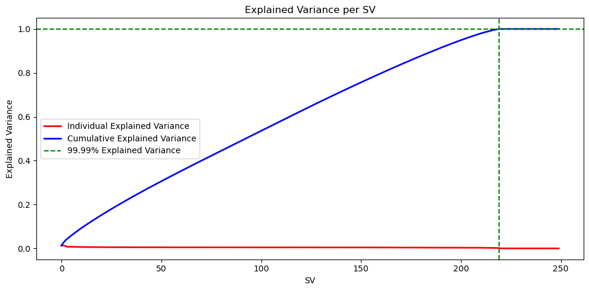

```python
plot_explained_var(t6_var_exp, 0.9999)
get_sv_num(t6_var_exp, 0.9999)
print("Figure 2.2. First Stage SV Explained Variance Table")
```

The initial SVD applied to the bag-of-words representation of keywords led to a significant reduction in the number of features required to explain the entirety of the text data. The graph displayed above, which was generated using the 'plot_explained_var' function, demonstrates that 100 percent explained variance can be achieved with just over 200 singular vectors (SVs).

Specifically, the 'get_sv_num' function yields an exact count of 220, which marks a substantial reduction from the initial dataset's 3061 columns.

[output not shown]

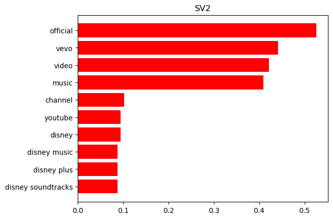

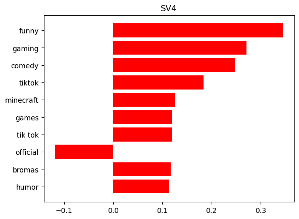

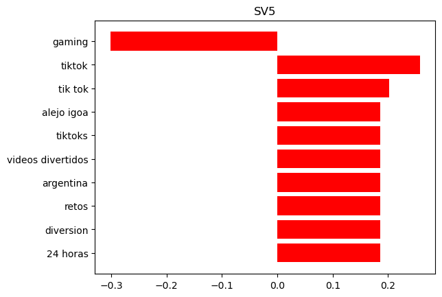

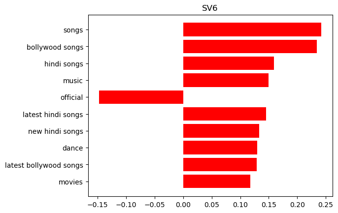

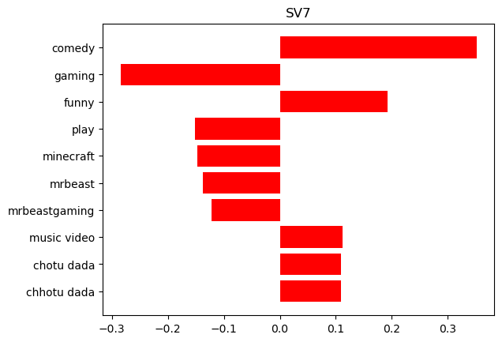

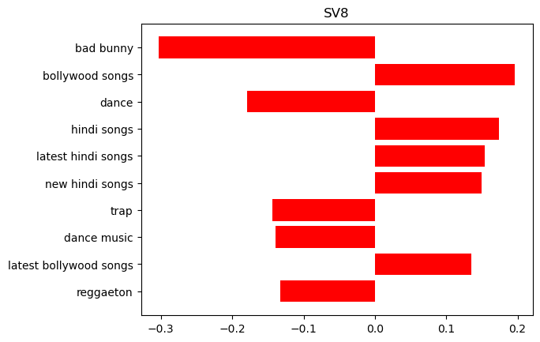

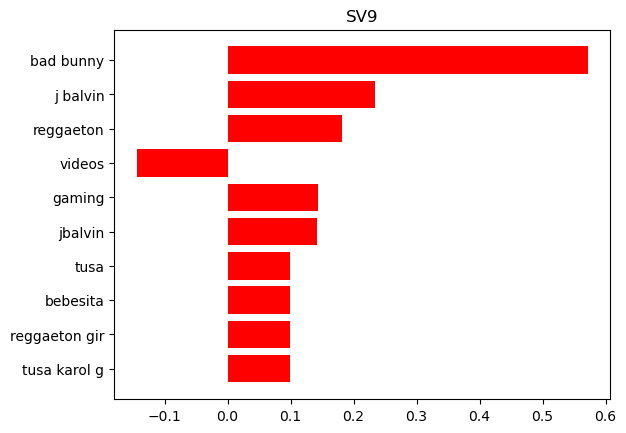

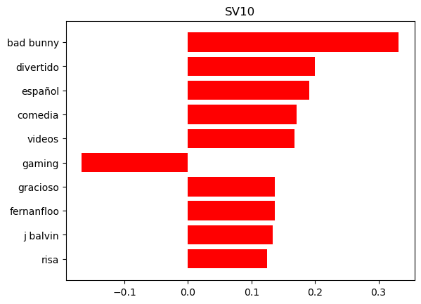

```python
print("Figure 2.3.Top 10 SVs Illustrated in the First Stage LSA")
plot_sv_bars(t6_text_svd_components, 10, t6_text_data.columns)
```

[output not shown]